# STATS 326/786

Week 7 Tutorial

# Problem 1

Dummy variables are very useful for time series regression. In this problem you will learn how to create your own trading day dummy variable for 2023 in New Zealand. Below is a `tsibble` with all the days in 2023.

```r
data <- tsibble(Date = make_date(2023, 1, 1) + 0:364,
                index = Date)
```

> Create a variable that determines the day of the week.

```r
data <- data %>%
  mutate(Day = weekdays(Date))
```

> Create a weekday dummy variable that is 1 if the day is a weekday, and 0 if it is a weekend.

```r
data <- data %>%
  mutate(Weekday = ifelse(Day %in% c("Monday", "Tuesday", "Wednesday", "Thursday", "Friday"), 1, 0))
```

> Create a public holiday dummy variable that is 1 if the date is a public holiday, and 0 otherwise. The public holidays for 2023 in New Zealand are: New Year’s Day (2023-01-01), Day after New Year’s Day (2023-01-02), Waitangi Day (2023-02-06), Good Friday (2023-04-07), Easter Monday (2023-04-10), ANZAC Day (2023-04-25), King’s Birthday (2023-06-05), Matariki (2023-07-14), Labour Day (2023-10-23), Christmas Day (2023-12-25), Boxing Day (2023-12-26).

```r
data <- data %>%
  mutate(Holiday = ifelse(Date %in% ymd(c("2023-01-01", "2023-01-02", "2023-02-06",
                                      "2023-04-07", "2023-04-10", "2023-04-25",
                                      "2023-06-05", "2023-07-14", "2023-10-23",
                                      "2023-12-25", "2023-12-26")), 1, 0))
```

> Create a trading day dummy variable that is 1 if the day is a weekday and not a public holiday, and 0 otherwise.

```r
data <- data %>%
  mutate(Tradingday = ifelse(Weekday & !Holiday, 1, 0))
```

# Problem 2

The data set `souvenirs` contains the monthly sales figures of a shop which opened in January 1987 and sells gifts, souvenirs, and novelties. The shop is situated on the wharf at a beach resort town in Queensland, Australia. The sales volume varies with the seasonal population of tourists. There is a large influx of visitors to the town at Christmas and for the local surfing festival, held every March since 1988. Over time, the shop has expanded its premises, range of products, and staff. Below is a plot of this time series.

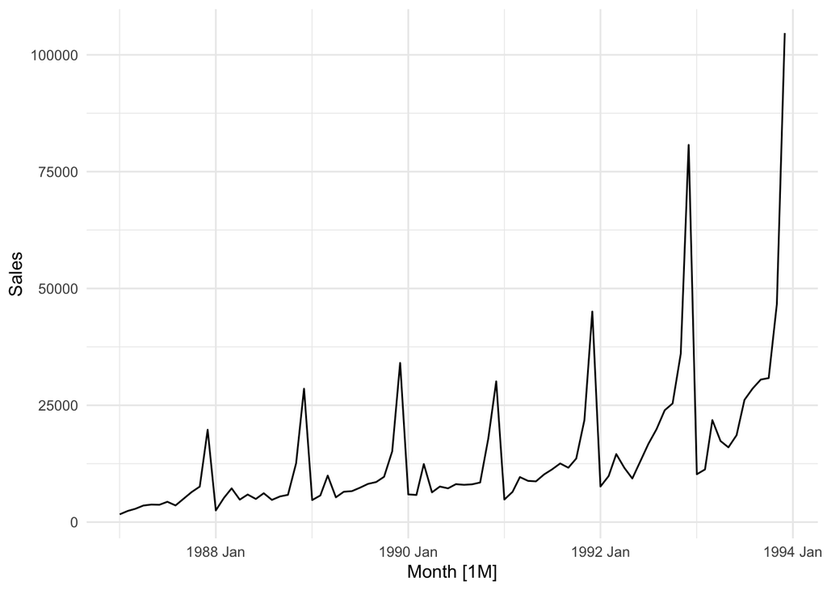

```r
data <- souvenirs
data %>%
  autoplot(Sales) +
  theme_minimal()
```

> Create a “surfing festival” dummy variable.

```r
data <- data %>%
  mutate(Festival = ifelse(month(Month) == 3 &
                           year(Month) >= 1988, 1, 0))
```

> Fit a regression model to the logarithm of these sales data with a linear trend, seasonal dummies, and a “surfing festival” dummy variable.

```r
# Fit model
fit <- data %>%
  model(m1 = TSLM(log(Sales) ~ trend() + season() + Festival))

# Report summary of model
fit %>%
  report()
```

```
## Series: Sales
## Model: TSLM
## Transformation: log(Sales)
##
## Residuals:
##       Min        1Q    Median        3Q       Max
## -0.336727 -0.127571  0.002568  0.109106  0.376714
##
## Coefficients:
##                 Estimate Std. Error t value Pr(>|t|)
## (Intercept)    7.6196670  0.0742471 102.626  < 2e-16 ***
## trend()        0.0220198  0.0008268  26.634  < 2e-16 ***
## season()year2  0.2514168  0.0956790   2.628 0.010555 *
## season()year3  0.2660828  0.1934044   1.376 0.173275
## season()year4  0.3840535  0.0957075   4.013 0.000148 ***
## season()year5  0.4094870  0.0957325   4.277 5.88e-05 ***
## season()year6  0.4488283  0.0957647   4.687 1.33e-05 ***
## season()year7  0.6104545  0.0958039   6.372 1.71e-08 ***
## season()year8  0.5879644  0.0958503   6.134 4.53e-08 ***
## season()year9  0.6693299  0.0959037   6.979 1.36e-09 ***
## season()year10 0.7473919  0.0959643   7.788 4.48e-11 ***
## season()year11 1.2067479  0.0960319  12.566  < 2e-16 ***
## season()year12 1.9622412  0.0961066  20.417  < 2e-16 ***
## Festival       0.5015151  0.1964273   2.553 0.012856 *
## ---
## Signif. codes:  0 '***' 0.001 '**' 0.01 '*' 0.05 '.' 0.1 ' ' 1
##
## Residual standard error: 0.179 on 70 degrees of freedom
## Multiple R-squared: 0.9567,  Adjusted R-squared: 0.9487
## F-statistic:   119 on 13 and 70 DF, p-value: < 2.22e-16
```

> Perform a model check to see whether the assumptions of time series regression are met.

Solution:

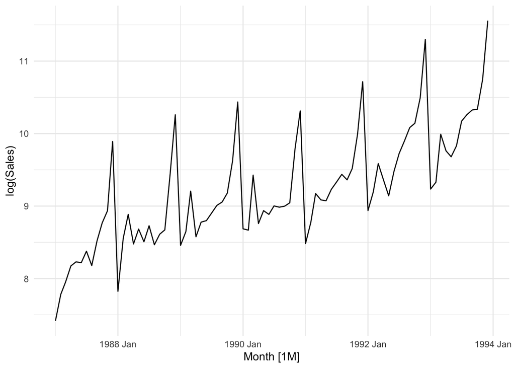

```r
# Linearity?
data %>%
  autoplot(log(Sales)) +
  theme_minimal()
```

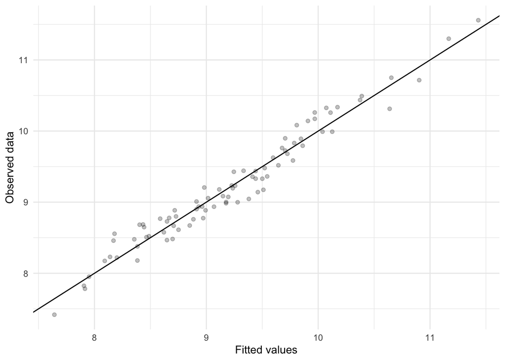

```r
# Can also look at fitted versus observed (on transformed scale)
augment(fit) %>%
  ggplot(aes(x = log(.fitted), y = log(Sales))) +
  geom_point(alpha = 0.25) +
  labs(x = "Fitted values",
       y = "Observed data") +
  geom_abline(intercept = 0, slope = 1) +
  theme_minimal()
```

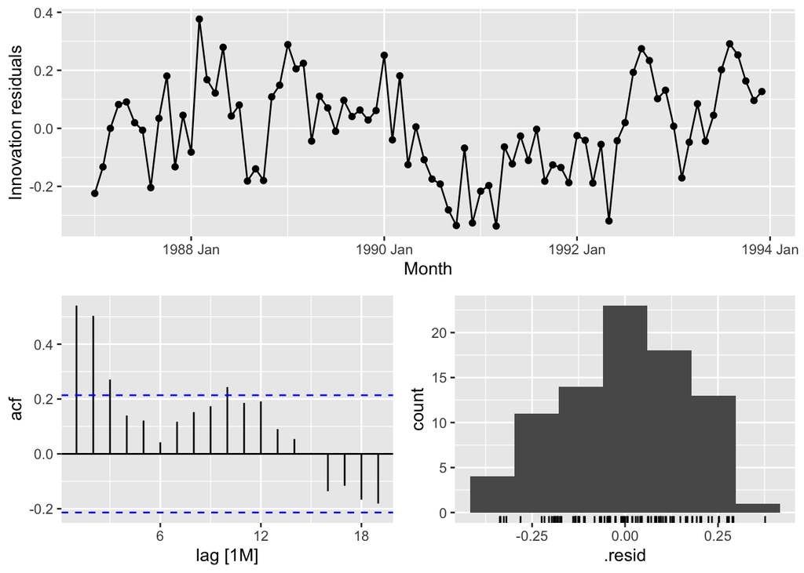

```r
# Independence, Normality, Equal Variance?
fit %>%
  gg_tsresiduals()
```

```r
# Perform Ljung-Box test
fit %>%
  augment() %>%
  features(.innov, features = ljung_box, lag = 24, dof = 14)
```

```
## # A tibble: 1 × 3
##   .model lb_stat lb_pvalue
##   <chr>    <dbl>     <dbl>
## 1 m1        112.         0
```

Recall the LINE acronym (linearity, independent, normality, equal variance). The log transformed data appears to be linear, as does the fitted versus observed values (on the log scale). The innovation residuals appear to be roughly 0 mean and approximately constant variance over time, although there is a slight slow-varying pattern over time. The innovation residuals appear to be normally distributed. The ACF plot and Ljung-Box test indicate significant residual autocorrelation. Therefore the innovation residuals are not independent, and the assumptions of the time series linear regression model are not all met.

> Regardless of your answers to the above questions, use your regression model to predict the monthly sales for 1994, 1995, and 1996. Produce prediction intervals for each of your forecasts.

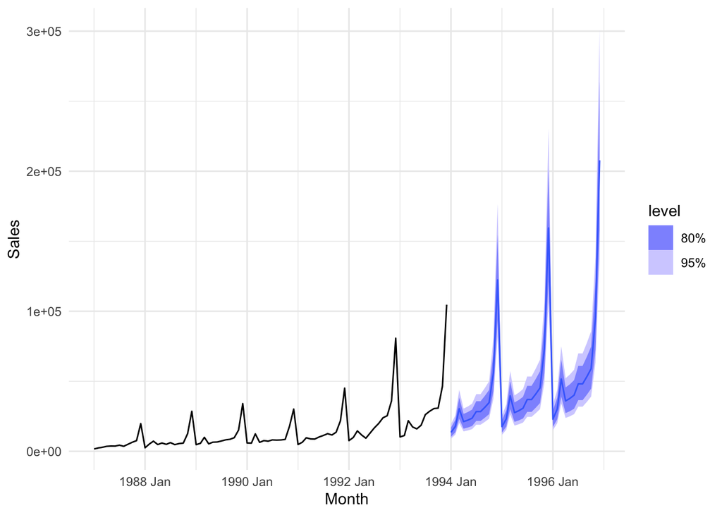

```r
# Create tsibble with surf festival dummy
future <- new_data(data, n = 36)  # Creates new tsibble
future <- future %>%
  mutate(Festival = rep(c(0, 0, 1, 0, 0, 0,
                          0, 0, 0, 0, 0, 0), 3))

# Forecast 3 years ahead
fc <- fit %>%
  forecast(new_data = future)

# Plot forecast
fc %>%
  autoplot(data) +
  theme_minimal()
```

> Refit the regression model, but use Fourier terms instead of seasonal dummies. Compare $K = 1, 2, 3, 4, 5, 6$ using AICc. Which model has the best fit?

```r
# Fit model
fit <- data %>%
  model(m1 = TSLM(log(Sales) ~ trend() + fourier(K = 1) + Festival),
        m2 = TSLM(log(Sales) ~ trend() + fourier(K = 2) + Festival),
        m3 = TSLM(log(Sales) ~ trend() + fourier(K = 3) + Festival),
        m4 = TSLM(log(Sales) ~ trend() + fourier(K = 4) + Festival),
        m5 = TSLM(log(Sales) ~ trend() + fourier(K = 5) + Festival),
        m6 = TSLM(log(Sales) ~ trend() + fourier(K = 6) + Festival))

# Report summary of model
glance(fit) %>%
  select(.model, AICc)
```

```
## # A tibble: 6 × 2
##   .model  AICc
##   <chr>  <dbl>
## 1 m1     -127.
## 2 m2     -151.
## 3 m3     -176.
## 4 m4     -209.
## 5 m5     -251.
## 6 m6     -267.
```

The best model is the one with $K = 6$ Fourier terms as this has the lowest AICc.